# Analysis of Auckland Summer Temperature

Bhuwan Aneja

2026-08-24

# Introduction

The importance of the variables used in predicting mean and maximum temperature are explored with regression trees and random forest models. The analysis additionally estimates the urban heat island effect and looks at the association between tree canopy cover and maximum temperature in urban areas.

# Data Preparation

```r
temperature_data <- read_csv(
  "Average_Daily_Air_Temperature_C_-6573379643131210635.csv"
)
dim(temperature_data)
```

```
## [1] 104181     25
```

```r
names(temperature_data)
```

```
##  [1] "OBJECTID"                      "Grid ID"
##  [3] "Mean air temperature at 2m"    "Minimum air temperature at 2m"
##  [5] "Maximum air temperature at 2m" "Altitude"
##  [7] "Canopy Height"                 "Building Height"
##  [9] "Irrigated"                     "Fraction of Trees"
## [11] "Fraction of Grass"             "Fraction of Paved Surfaces"
## [13] "Fraction of Buildings"         "Fraction of Bare Soil"
## [15] "Fraction of Water"             "Fraction of Albedo Buildings"
## [17] "Fraction Albedo Paved"         "Population Density"
## [19] "VALIDATIONSTATE"               "created_user"
## [21] "created_date"                  "last_edited_user"
## [23] "last_edited_date"              "Shape__Area"
## [25] "Shape__Length"
```

```r
head(temperature_data)
```

```
## # A tibble: 6 × 25
##   OBJECTID `Grid ID` `Mean air temperature at 2m` Minimum air temperature at 2…¹
##      <dbl> <chr>                            <dbl>                          <dbl>
## 1        1 AD-237                            18.9                           16.1
## 2        2 AF-248                            18.3                           16.1
## 3        3 AG-235                            19.0                           16.0
## 4        4 AG-245                            18.8                           16.0
## 5        5 AG-246                            18.8                           16.0
## 6        6 AH-240                            18.9                           16.1
## # ℹ abbreviated name: ¹`Minimum air temperature at 2m`
## # ℹ 21 more variables: `Maximum air temperature at 2m` <dbl>, Altitude <dbl>,
## #   `Canopy Height` <dbl>, `Building Height` <dbl>, Irrigated <dbl>,
## #   `Fraction of Trees` <dbl>, `Fraction of Grass` <dbl>,
## #   `Fraction of Paved Surfaces` <dbl>, `Fraction of Buildings` <dbl>,
## #   `Fraction of Bare Soil` <dbl>, `Fraction of Water` <dbl>,
## #   `Fraction of Albedo Buildings` <dbl>, `Fraction Albedo Paved` <dbl>, …
```

```r
summary(temperature_data)
```

```
##     OBJECTID        Grid ID          Mean air temperature at 2m
##  Min.   :     1   Length:104181      Min.   :16.11
##  1st Qu.: 26046   Class :character   1st Qu.:18.24
##  Median : 52091   Mode  :character   Median :18.47
##  Mean   : 52091                      Mean   :18.43
##  3rd Qu.: 78136                      3rd Qu.:18.71
##  Max.   :104181                      Max.   :19.83
##  Minimum air temperature at 2m Maximum air temperature at 2m    Altitude
##  Min.   :13.37                 Min.   :18.98                 Min.   : -0.8259
##  1st Qu.:14.78                 1st Qu.:21.78                 1st Qu.: 24.1008
##  Median :15.22                 Median :22.40                 Median : 53.8297
##  Mean   :15.28                 Mean   :22.22                 Mean   : 76.0257
##  3rd Qu.:15.74                 3rd Qu.:22.82                 3rd Qu.:102.4161
##  Max.   :18.14                 Max.   :23.94                 Max.   :665.6925
##  Canopy Height    Building Height      Irrigated       Fraction of Trees
##  Min.   : 0.000   Min.   :-0.08655   Min.   :0.00000   Min.   :0.00000
##  1st Qu.: 4.966   1st Qu.: 0.00000   1st Qu.:0.00000   1st Qu.:0.06369
##  Median : 7.000   Median : 0.00000   Median :0.00000   Median :0.19303
##  Mean   : 7.563   Mean   : 1.01394   Mean   :0.04686   Mean   :0.33662
##  3rd Qu.: 9.492   3rd Qu.: 2.41131   3rd Qu.:0.00000   3rd Qu.:0.57867
##  Max.   :30.000   Max.   :36.14413   Max.   :1.00000   Max.   :1.00000
##  Fraction of Grass Fraction of Paved Surfaces Fraction of Buildings
##  Min.   :0.0000    Min.   :0.000000           Min.   :0.000000
##  1st Qu.:0.1750    1st Qu.:0.000000           1st Qu.:0.000000
##  Median :0.5307    Median :0.001481           Median :0.000000
##  Mean   :0.5076    Mean   :0.054007           Mean   :0.023738
##  3rd Qu.:0.8359    3rd Qu.:0.045369           3rd Qu.:0.006345
##  Max.   :1.0000    Max.   :0.991033           Max.   :1.000000
##  Fraction of Bare Soil Fraction of Water  Fraction of Albedo Buildings
##  Min.   :0.000000      Min.   :0.000000   Min.   :0.00000
##  1st Qu.:0.000000      1st Qu.:0.000000   1st Qu.:0.08363
##  Median :0.000000      Median :0.000000   Median :0.09604
##  Mean   :0.027749      Mean   :0.050271   Mean   :0.09564
##  3rd Qu.:0.005965      3rd Qu.:0.001038   3rd Qu.:0.11176
##  Max.   :1.000000      Max.   :0.989992   Max.   :0.52463
##  Fraction Albedo Paved Population Density VALIDATIONSTATE created_user
##  Min.   :0             Min.   :  0.000    Min.   :3       Mode:logical
##  1st Qu.:0             1st Qu.:  0.040    1st Qu.:3       NA's:104181
##  Median :0             Median :  0.120    Median :3
##  Mean   :0             Mean   :  3.016    Mean   :3
##  3rd Qu.:0             3rd Qu.:  0.420    3rd Qu.:3
##  Max.   :0             Max.   :396.710    Max.   :3
##  created_date   last_edited_user last_edited_date  Shape__Area
##  Mode:logical   Mode:logical     Mode:logical     Min.   :50000
##  NA's:104181    NA's:104181      NA's:104181      1st Qu.:50000
##                                                   Median :50000
##                                                   Mean   :50000
##                                                   3rd Qu.:50000
##                                                   Max.   :50000
##  Shape__Length
##  Min.   :832.4
##  1st Qu.:832.4
##  Median :832.4
##  Mean   :832.4
##  3rd Qu.:832.4
##  Max.   :832.4
```

```r
apply(
  temperature_data,
  2,
  function(x) sum(is.na(x))
)
```

```
##                      OBJECTID                       Grid ID
##                             0                             0
##    Mean air temperature at 2m Minimum air temperature at 2m
##                             0                             0
## Maximum air temperature at 2m                      Altitude
##                             0                             0
##                 Canopy Height               Building Height
##                             0                             0
##                     Irrigated             Fraction of Trees
##                             0                             0
##             Fraction of Grass    Fraction of Paved Surfaces
##                             0                             0
##         Fraction of Buildings         Fraction of Bare Soil
##                             0                             0
##             Fraction of Water  Fraction of Albedo Buildings
##                             0                             0
##         Fraction Albedo Paved            Population Density
##                             0                             0
##               VALIDATIONSTATE                  created_user
##                             0                        104181
##                  created_date              last_edited_user
##                        104181                        104181
##              last_edited_date                   Shape__Area
##                        104181                             0
##                 Shape__Length
##                             0
```

```r
temperature_data_clean <- temperature_data |>
  select(
    -OBJECTID,
    -VALIDATIONSTATE,
    -created_user,
    -created_date,
    -last_edited_user,
    -last_edited_date,
    -Shape__Area,
    -Shape__Length
  )

dim(temperature_data_clean)
```

```
## [1] 104181     17
```

The dataset contains 104,181 records representing grid locations across Auckland. Each observation includes temperature measurements and information about landcover characteristics.

Initial checks were performed to confirm the structure of the dataset and identify any missing values. Several metadata variables contained only missing values and were removed before modelling.

# Question 1

```r
# Creating coordinates from Grid ID
temperature_map <- temperature_data_clean |>
  separate(
    `Grid ID`,
    into = c("east_letter", "north"),
    sep = "-"
  ) |>
  mutate(
    east = (match(substr(east_letter, 1, 1), LETTERS) - 1) * 26 +
      match(substr(east_letter, 2, 2), LETTERS),
    north = as.numeric(north)
  )


# Checking that coordinates were created correctly
head(
  temperature_map |>
    select(east_letter, east, north)
)
```

```
## # A tibble: 6 × 3
##   east_letter  east north
##   <chr>       <dbl> <dbl>
## 1 AD              4   237
## 2 AF              6   248
## 3 AG              7   235
## 4 AG              7   245
## 5 AG              7   246
## 6 AH              8   240
```

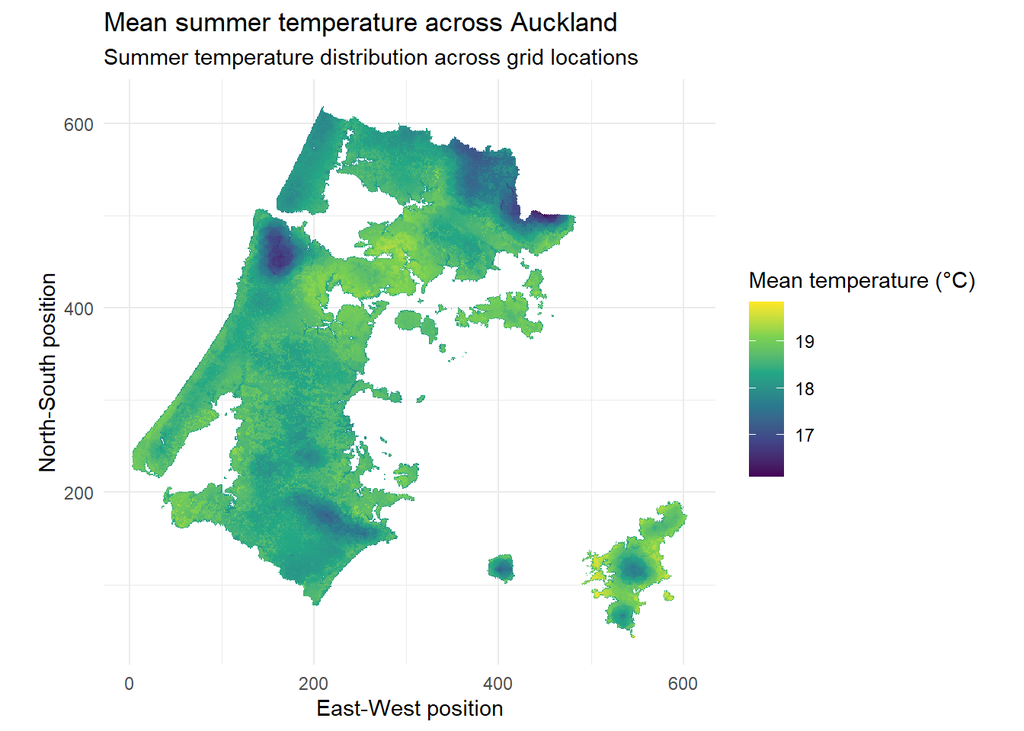

```r
# Plotting mean temperature map

ggplot(
  temperature_map,
  aes(
    x = east,
    y = north,
    fill = `Mean air temperature at 2m`
  )
) +
  geom_tile() +
  scale_fill_viridis_c() +
  coord_equal() +
  labs(
    title = "Mean summer temperature across Auckland",
    subtitle = "Summer temperature distribution across grid locations",
    x = "East-West position",
    y = "North-South position",
    fill = "Mean temperature (°C)"
  ) +
  theme_minimal()
```

```r
# Checking temperature range

range(
  temperature_map$`Mean air temperature at 2m`
)
```

```
## [1] 16.11222 19.83416
```

```r
# Summary statistics

summary(
  temperature_map$`Mean air temperature at 2m`
)
```

```
##    Min. 1st Qu.  Median    Mean 3rd Qu.    Max.
##   16.11   18.24   18.47   18.43   18.71   19.83
```

The map shows that mean summer temperature varies across Auckland, with some regions being warmer than others. The temperature values range from approximately 16.1°C to 19.8°C, with an average temperature of around 18.4°C. The spatial variation suggests that local environmental characteristics influence temperature patterns. Factors such as altitude, vegetation, water coverage and urban development may contribute to differences in temperature between locations.

# Question 2

A regression tree was fitted to predict mean summer temperature using landcover variables. The model uses environmental characteristics such as altitude, vegetation, buildings, water coverage and population density as predictors.

```r
# Selecting variables for regression tree

mean_temperature_data <- temperature_data_clean |>
  select(
    `Mean air temperature at 2m`,
    Altitude,
    `Canopy Height`,
    `Building Height`,
    Irrigated,
    `Fraction of Trees`,
    `Fraction of Grass`,
    `Fraction of Paved Surfaces`,
    `Fraction of Buildings`,
    `Fraction of Bare Soil`,
    `Fraction of Water`,
    `Fraction of Albedo Buildings`,
    `Fraction Albedo Paved`,
    `Population Density`
  )

# Fitting regression tree

mean_temperature_tree <- rpart(
  `Mean air temperature at 2m` ~ .,
  data = mean_temperature_data,
  method = "anova"
)
# Displaying tree output

mean_temperature_tree
```

```
## n= 104181
##
## node), split, n, deviance, yval
##       * denotes terminal node
##
##   1) root 104181 19550.9900 18.43461
##     2) Altitude>=153.1414 13717  3957.1460 17.83014
##       4) Altitude>=276.6492 2796   836.8470 17.43506 *
##       5) Altitude< 276.6492 10921  2572.1570 17.93128
##        10) Population Density>=0.215 2476   421.6202 17.68202 *
##        11) Population Density< 0.215 8445  1951.5990 18.00436 *
##     3) Altitude< 153.1414 90464  9821.8770 18.52626
##       6) Fraction of Buildings< 0.07425792 80032  7805.5570 18.48068
##        12) Fraction of Trees< 0.2519938 47179  3671.3350 18.41528
##          24) Altitude>=65.87327 12031   967.1696 18.23151 *
##          25) Altitude< 65.87327 35148  2158.7480 18.47819
##            50) Fraction of Water>=0.5384224 3923   224.8293 18.18212 *
##            51) Fraction of Water< 0.5384224 31225  1546.8230 18.51539
##             102) Population Density>=0.035 26324  1065.8140 18.47914 *
##             103) Population Density< 0.035 4901   260.7031 18.71006 *
##        13) Fraction of Trees>=0.2519938 32853  3642.7760 18.57458
##          26) Altitude>=86.39057 11687  1547.7510 18.44183 *
##          27) Altitude< 86.39057 21166  1775.3620 18.64788 *
##       7) Fraction of Buildings>=0.07425792 10432   573.9508 18.87601 *
```

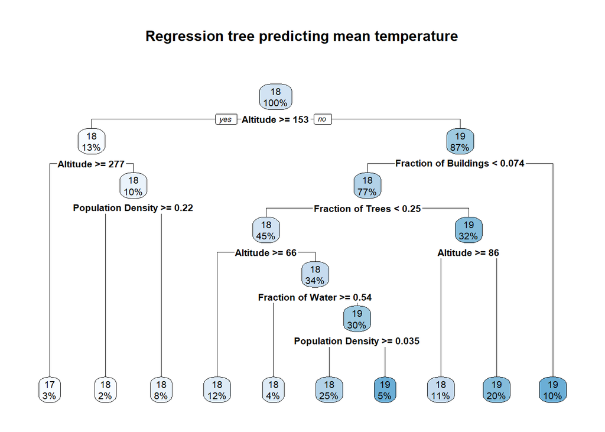

```r
# Plotting regression tree

rpart.plot(
  mean_temperature_tree,
  main = "Regression tree predicting mean temperature"
)
```

```r
# Complexity parameter table
printcp(mean_temperature_tree)
```

```
##
## Regression tree:
## rpart(formula = `Mean air temperature at 2m` ~ ., data = mean_temperature_data,
##     method = "anova")
##
## Variables actually used in tree construction:
## [1] Altitude              Fraction of Buildings Fraction of Trees
## [4] Fraction of Water     Population Density
##
## Root node error: 19551/104181 = 0.18766
##
## n= 104181
##
##         CP nsplit rel error  xerror      xstd
## 1 0.295226      0   1.00000 1.00001 0.0061280
## 2 0.073775      1   0.70477 0.70601 0.0036526
## 3 0.028037      2   0.63100 0.63207 0.0035714
## 4 0.026517      3   0.60296 0.61216 0.0033758
## 5 0.019799      5   0.54993 0.54564 0.0031605
## 6 0.016350      6   0.53013 0.52847 0.0031193
## 7 0.011268      7   0.51378 0.51378 0.0030550
## 8 0.010175      8   0.50251 0.50071 0.0030460
## 9 0.010000      9   0.49234 0.49316 0.0030372
```

The regression tree showed that the most important predictor of mean temperature was the altitude, which was chosen as the first splitting variable in the regression tree. The predicted temperatures were lower at higher altitude sites, reflecting the expected decrease in temperatures with elevation. Fraction of buildings, fraction of trees, fraction of water and population density were some other important variables selected by the tree. The variables indicate that there are factors other than the urban development influencing the variation in mean temperature across Auckland; these are natural features.

The overall mean temperature was the worst predictor in terms of minimizing the prediction error, indicating that landcover variables can be useful for explaining temperature differences between locations.

# Question 3

A regression tree was fitted to predict maximum summer temperature using the same landcover variables. Maximum temperature represents the hottest conditions experienced across Auckland, so variables related to vegetation, altitude and urban development may have a stronger influence.

```r
# Selecting variables for regression tree
maximum_temperature_data <- temperature_data_clean |>
  select(
    `Maximum air temperature at 2m`,
    Altitude,
    `Canopy Height`,
    `Building Height`,
    Irrigated,
    `Fraction of Trees`,
    `Fraction of Grass`,
    `Fraction of Paved Surfaces`,
    `Fraction of Buildings`,
    `Fraction of Bare Soil`,
    `Fraction of Water`,
    `Fraction of Albedo Buildings`,
    `Fraction Albedo Paved`,
    `Population Density`
  )
# Fitting regression tree
maximum_temperature_tree <- rpart(
  `Maximum air temperature at 2m` ~ .,
  data = maximum_temperature_data,
  method = "anova"
)
# Displaying tree output

maximum_temperature_tree
```

```
## n= 104181
##
## node), split, n, deviance, yval
##       * denotes terminal node
##
##  1) root 104181 65651.6500 22.22338
##    2) Fraction of Grass< 0.1838834 26764 18138.2200 21.49381
##      4) Altitude>=189.5747 5662  2516.6530 20.72764
##        8) Population Density< 0.025 2416   620.5565 20.32920 *
##        9) Population Density>=0.025 3246  1227.0570 21.02420 *
##      5) Altitude< 189.5747 21102 11406.0600 21.69939
##       10) Fraction of Water>=0.5116579 4051  1812.2840 21.08398 *
##       11) Fraction of Water< 0.5116579 17051  7695.0570 21.84560
##         22) Population Density< 0.075 9281  4083.5770 21.59266 *
##         23) Population Density>=0.075 7770  2308.4200 22.14773 *
##    3) Fraction of Grass>=0.1838834 77417 28342.8800 22.47560
##      6) Population Density< 0.075 23750 10717.9600 22.11702
##       12) Altitude>=154.2735 2469  1068.3680 21.41958 *
##       13) Altitude< 154.2735 21281  8309.2790 22.19794
##         26) Fraction of Water>=0.2064369 1445   755.4115 21.53709 *
##         27) Fraction of Water< 0.2064369 19836  6876.8270 22.24608 *
##      7) Population Density>=0.075 53667 13219.7500 22.63429
##       14) Altitude>=108.0375 7515  1704.2830 22.15599 *
##       15) Altitude< 108.0375 46152  9516.2910 22.71217 *
```

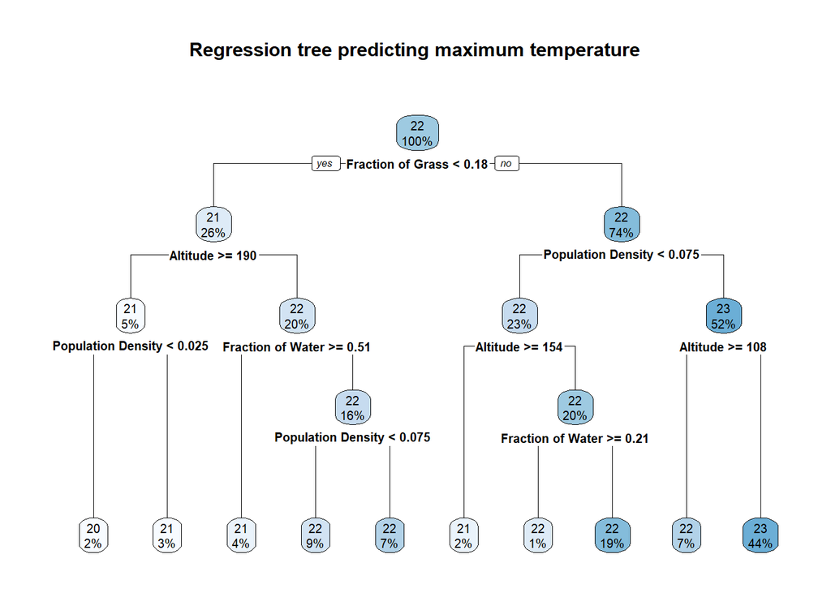

```r
# Plotting regression tree

rpart.plot(
  maximum_temperature_tree,
  main = "Regression tree predicting maximum temperature"
)
```

```r
# Complexity parameter table

printcp(maximum_temperature_tree)
```

```
##
## Regression tree:
## rpart(formula = `Maximum air temperature at 2m` ~ ., data = maximum_temperature_data,
##     method = "anova")
##
## Variables actually used in tree construction:
## [1] Altitude           Fraction of Grass  Fraction of Water  Population Density
##
## Root node error: 65652/104181 = 0.63017
##
## n= 104181
##
##          CP nsplit rel error  xerror      xstd
## 1  0.292004      0   1.00000 1.00002 0.0047680
## 2  0.067099      1   0.70800 0.70806 0.0032427
## 3  0.064210      2   0.64090 0.64094 0.0029551
## 4  0.030451      3   0.57669 0.57716 0.0027083
## 5  0.028921      4   0.54624 0.54718 0.0026549
## 6  0.020416      5   0.51731 0.51868 0.0024931
## 7  0.019848      6   0.49690 0.50317 0.0024058
## 8  0.010313      7   0.47705 0.48567 0.0023196
## 9  0.010191      8   0.46674 0.47551 0.0022531
## 10 0.010000      9   0.45655 0.46569 0.0021846
```

Fraction of grass was the first and most important split variable in the regression tree for maximum temperature. This indicates that the amount of vegetation cover is a significant factor in the variation in Auckland’s maximum temperatures. Altitude and fraction of water and population density were also shown to be important predictors for the tree.

Predicted maximum temperatures were lower at higher altitudes and higher in areas of higher population density. The same applied to water coverage as a cooling effect. The overall tree indicates the influence of both natural and urban attributes on maximum temperature.

# Question 4

A random forest model was fitted to predict mean summer temperature using the same landcover variables used in the regression tree. Random forests combine many regression trees, which can improve prediction accuracy by reducing the variability of a single tree.

```r
# Preparing data for ranger by simplifying variable names

mean_temperature_rf_data <- mean_temperature_data |>
  rename_with(
    ~ make.names(.)
  )
# Splitting data into training and testing sets

set.seed(369)

train_index <- sample(
  1:nrow(mean_temperature_rf_data),
  0.8 * nrow(mean_temperature_rf_data)
)

mean_train <- mean_temperature_rf_data[train_index, ]

mean_test <- mean_temperature_rf_data[-train_index, ]

# Fitting random forest model

mean_rf <- ranger(
  Mean.air.temperature.at.2m ~ .,
  data = mean_train,
  importance = "permutation"
)
# Displaying model information
mean_rf
```

```
## Ranger result
##
## Call:
##  ranger(Mean.air.temperature.at.2m ~ ., data = mean_train, importance = "permutation")
##
## Type:                             Regression
## Number of trees:                  500
## Sample size:                      83344
## Number of independent variables:  13
## Mtry:                             3
## Target node size:                 5
## Variable importance mode:         permutation
## Splitrule:                        variance
## OOB prediction error (MSE):       0.05123874
## R squared (OOB):                  0.7269038
```

```r
# Predicting on test data

mean_predictions <- predict(
  mean_rf,
  mean_test
)$predictions


# Calculating test MSE

mean_rf_mse <- mean(
  (mean_test$Mean.air.temperature.at.2m -
     mean_predictions)^2
)
mean_rf_mse
```

```
## [1] 0.05191367
```

```r
# Variable importance
sort(
  mean_rf$variable.importance,
  decreasing = TRUE
)
```

```
##                     Altitude            Fraction.of.Trees
##                 0.1892378301                 0.0571409241
##           Population.Density            Fraction.of.Grass
##                 0.0501111069                 0.0447889154
##            Fraction.of.Water   Fraction.of.Paved.Surfaces
##                 0.0250949221                 0.0201849342
## Fraction.of.Albedo.Buildings        Fraction.of.Buildings
##                 0.0196236626                 0.0145743002
##                Canopy.Height        Fraction.of.Bare.Soil
##                 0.0141580960                 0.0112461133
##              Building.Height                    Irrigated
##                 0.0082946327                 0.0007870972
##        Fraction.Albedo.Paved
##                 0.0000000000
```

The out of bag prediction error of the random forest model was about 0.051 and the test MSE was about 0.052, using 500 trees. This is a significant improvement over the single regression tree, which was achieving a higher prediction error.

This is because in the random forest, predictions are made by multiple trees, resulting in lower variance for the forest, and improved predictions for unseen data.

# Question 5

A random forest model was fitted to predict maximum summer temperature using landcover variables. The model performance is compared with the regression tree from Question 3 to evaluate whether combining multiple trees improves prediction accuracy.

```r
# Preparing data for ranger by simplifying variable names

maximum_temperature_rf_data <- maximum_temperature_data |>
  rename_with(
    ~ make.names(.)
  )
# Splitting data into training and testing sets

set.seed(369)
train_index_max <- sample(
  1:nrow(maximum_temperature_rf_data),
  0.8 * nrow(maximum_temperature_rf_data)
)

max_train <- maximum_temperature_rf_data[train_index_max, ]

max_test <- maximum_temperature_rf_data[-train_index_max, ]

# Fitting random forest model

max_rf <- ranger(
  Maximum.air.temperature.at.2m ~ .,
  data = max_train,
  importance = "permutation"
)
# Displaying model information
max_rf
```

```
## Ranger result
##
## Call:
##  ranger(Maximum.air.temperature.at.2m ~ ., data = max_train, importance = "permutation")
##
## Type:                             Regression
## Number of trees:                  500
## Sample size:                      83344
## Number of independent variables:  13
## Mtry:                             3
## Target node size:                 5
## Variable importance mode:         permutation
## Splitrule:                        variance
## OOB prediction error (MSE):       0.1543392
## R squared (OOB):                  0.7549116
```

```r
# Predicting on test data

max_predictions <- predict(
  max_rf,
  max_test
)$predictions


# Calculating test MSE

max_rf_mse <- mean(
  (max_test$Maximum.air.temperature.at.2m -
     max_predictions)^2
)

max_rf_mse
```

```
## [1] 0.1551762
```

```r
# Variable importance

sort(
  max_rf$variable.importance,
  decreasing = TRUE
)
```

```
##                     Altitude            Fraction.of.Grass
##                  0.236074885                  0.194664318
##           Population.Density            Fraction.of.Trees
##                  0.177933266                  0.156099951
##            Fraction.of.Water                Canopy.Height
##                  0.126487593                  0.053780989
##   Fraction.of.Paved.Surfaces        Fraction.of.Buildings
##                  0.050853144                  0.041918198
## Fraction.of.Albedo.Buildings        Fraction.of.Bare.Soil
##                  0.033925108                  0.025471841
##              Building.Height                    Irrigated
##                  0.024828884                  0.004890433
##        Fraction.Albedo.Paved
##                  0.000000000
```

Out of bag prediction error of the random forest model was about 0.154 and the test MSE was about 0.155 for predicting the maximum temperature. This was significantly less than the regression tree found in Question 3 indicating that the random forest was more successful at predicting.

This is because the random forest is better generalising to the unseen data due to the averaging of many trees, which lessens the variance of individual trees.

# Question 6

The urban heat island effect describes the difference in temperature between urban and nonurban areas. A simple comparison may be misleading because locations can differ in altitude, vegetation, water coverage and building density. Therefore, a regression model was used to estimate the urban effect while controlling for other environmental characteristics.

```r
# Creating urban and nonurban categories using population density

temperature_uhi <- temperature_data_clean |>
  mutate(
    urban = if_else(
      `Population Density` >
        median(`Population Density`),
      "Urban",
      "Non-urban"
    )
  )
# Checking number of observations in each group

table(temperature_uhi$urban)
```

```
##
## Non-urban     Urban
##     52639     51542
```

```r
# Comparing mean temperature between groups

temperature_uhi |>
  group_by(urban) |>
  summarise(
    mean_temperature =
      mean(`Mean air temperature at 2m`),
    median_temperature =
      median(`Mean air temperature at 2m`),
    number_of_locations = n()
  )
```

```
## # A tibble: 2 × 4
##   urban     mean_temperature median_temperature number_of_locations
##   <chr>                <dbl>              <dbl>               <int>
## 1 Non-urban             18.4               18.4               52639
## 2 Urban                 18.5               18.5               51542
```

```r
# Fitting regression model controlling for other factors

uhi_model <- lm(
  `Mean air temperature at 2m` ~
    urban +
    Altitude +
    `Fraction of Trees` +
    `Fraction of Water` +
    `Fraction of Buildings`,
  data = temperature_uhi
)
# Model results
summary(uhi_model)
```

```
##
## Call:
## lm(formula = `Mean air temperature at 2m` ~ urban + Altitude +
##     `Fraction of Trees` + `Fraction of Water` + `Fraction of Buildings`,
##     data = temperature_uhi)
##
## Residuals:
##      Min       1Q   Median       3Q      Max
## -1.91668 -0.16732 -0.00702  0.16727  1.61919
##
## Coefficients:
##                           Estimate Std. Error t value Pr(>|t|)
## (Intercept)              1.869e+01  2.049e-03  9119.2   <2e-16 ***
## urbanUrban              -6.852e-02  2.015e-03   -34.0   <2e-16 ***
## Altitude                -4.492e-03  1.479e-05  -303.7   <2e-16 ***
## `Fraction of Trees`      3.353e-01  3.260e-03   102.9   <2e-16 ***
## `Fraction of Water`     -6.193e-01  5.592e-03  -110.8   <2e-16 ***
## `Fraction of Buildings`  1.645e+00  1.493e-02   110.1   <2e-16 ***
## ---
## Signif. codes:  0 '***' 0.001 '**' 0.01 '*' 0.05 '.' 0.1 ' ' 1
##
## Residual standard error: 0.2949 on 104175 degrees of freedom
## Multiple R-squared:  0.5366, Adjusted R-squared:  0.5366
## F-statistic: 2.412e+04 on 5 and 104175 DF,  p-value: < 2.2e-16
```

The urban heat island effect was estimated by comparing urban and non-urban sites, after accounting for other factors which affect temperature such as altitude, trees, water, and buildings. The mean temperature was slightly higher in urban areas than in nonurban areas, as revealed by a simple comparison. With other factors accounted for, the urban effect was calculated to be around -0.07°C. This indicates that urbanization density is not a good indicator of urbanization in every situation and other landcover properties are more influential on the difference in temperature.

The model indicated that the building coverage was related to higher temperatures, and altitude and water coverage to lower temperatures. This shows that variations in temperature across Auckland are due to both urban and natural features.

One drawback of this analysis is that population density was the only criterion used to outline urban areas. While population density is a good indicator of urbanisation, it is not a complete indicator of all aspects of urban life, including building density, road coverage or land use. More likely, a more detailed classification of urban areas might result in another estimate of the urban heat island effect.

# Question 7

To estimate the effect of tree cover, the analysis was restricted to urban Auckland locations. This provides a more appropriate comparison because tree covered and nontree covered areas may differ in other characteristics such as altitude, buildings, paved surfaces and water coverage. A regression model was used to estimate the relationship between tree cover and maximum temperature while controlling for these factors.

```r
# Selecting only urban locations
urban_temperature <- temperature_uhi |>
  filter(
    urban == "Urban"
  )

# Checking number of urban observations
dim(urban_temperature)
```

```
## [1] 51542    18
```

```r
# Fitting regression model
tree_effect_model <- lm(
  `Maximum air temperature at 2m` ~
    `Fraction of Trees` +
    Altitude +
    `Fraction of Buildings` +
    `Fraction of Paved Surfaces` +
    `Fraction of Water` +
    `Population Density`,
  data = urban_temperature
)
# Model results
summary(tree_effect_model)
```

```
##
## Call:
## lm(formula = `Maximum air temperature at 2m` ~ `Fraction of Trees` +
##     Altitude + `Fraction of Buildings` + `Fraction of Paved Surfaces` +
##     `Fraction of Water` + `Population Density`, data = urban_temperature)
##
## Residuals:
##      Min       1Q   Median       3Q      Max
## -2.16573 -0.18847  0.06325  0.27305  1.38599
##
## Coefficients:
##                                Estimate Std. Error  t value Pr(>|t|)
## (Intercept)                   2.314e+01  3.778e-03 6124.468  < 2e-16 ***
## `Fraction of Trees`          -4.913e-01  7.821e-03  -62.816  < 2e-16 ***
## Altitude                     -5.333e-03  3.817e-05 -139.712  < 2e-16 ***
## `Fraction of Buildings`      -5.103e-01  4.423e-02  -11.539  < 2e-16 ***
## `Fraction of Paved Surfaces` -4.791e-01  2.525e-02  -18.974  < 2e-16 ***
## `Fraction of Water`          -2.287e+00  1.638e-02 -139.653  < 2e-16 ***
## `Population Density`          1.234e-03  2.050e-04    6.019 1.77e-09 ***
## ---
## Signif. codes:  0 '***' 0.001 '**' 0.01 '*' 0.05 '.' 0.1 ' ' 1
##
## Residual standard error: 0.4175 on 51535 degrees of freedom
## Multiple R-squared:  0.465,  Adjusted R-squared:  0.4649
## F-statistic:  7464 on 6 and 51535 DF,  p-value: < 2.2e-16
```

Tree cover was estimated only at urban locations, and was adjusted for other environmental factors when determining the effect on maximum temperature. The coefficient for fraction of trees was negative (-0.491), which means that locations where there is more tree cover have lower maximum temperatures when other factors are controlled for. A 0.1 change in fraction of tree cover corresponds to about 0.05°C change in maximum temperature, due to the range of the fraction of trees (0-1).

Other factors also had an influence on maximum temperature. The altitude and water coverage indicated cooling effects with a slight warming effect for the population density. Around 46.5% of the variation in the maximum temperature over urban areas was explained by the model.

The overall results indicate a link between higher tree cover and lower maximum temperature in urban Auckland, with other land cover features also being significant.

# Conclusion

This analysis explored the relationship between environmental and urban factors with summer temperature trends throughout Auckland. The temperature map indicated that there was spatial variation, which means that the temperature varies according to the different land characteristics.

Important predictors of both mean and maximum temperature were identified by regression trees. Fraction of grass was an important predictor of maximum temperature with altitude being a significant predictor of mean temperature. The results indicate that there is interplay between natural and urban features and the temperature pattern.

The random forest models predicted much better than individual regression trees. The random forest models had prediction errors lower than the single tree models since the noise and error of each tree were averaged out with the combination of many trees.

It was found from the analysis of the urban heat island that the temperature difference between urban and nonurban areas is not only a function of population. Building coverage, vegetation, water coverage and altitude are important modifiers of temperature as well. The tree cover analysis indicated urban vegetation greenness was negatively correlated to maximum temperatures in urban Auckland, indicating there is potential for the urban vegetation to play a role in reducing heat exposure.

The overall results indicate that there is interaction between land cover, natural features and urban development that affects Auckland’s summer temperature patterns.

# Citations and Acknowledgements

The statistical methods used in this report, including regression trees, random forests, model comparison and variable importance, were based on concepts covered in the STATS 369 lecture notes and course materials.

R packages used in this analysis include:

- `tidyverse` for data manipulation and visualisation.
- `rpart` and `rpart.plot` for regression tree modelling and visualisation.
- `ranger` for random forest modelling.
- `viridis` for colour scales in visualisations.

In addition, I used ChatGPT to help improve the layout and readability of the R code, identify formatting and syntax issues, and organise some of the written explanations. I ran all code myself in RStudio, checked the outputs and graphs, and based the final interpretations on the results produced by my analysis.